# An introduction to spatial data in R

Jacinta Kong

06-10-2021

# Introduction

This is going to be an introduction to a simple workflow for spatial data in R using rasters. I will assume you have some basic knowledge about spatial analyses and co-ordinate systems. This is not meant to be a documentation of the full suite of spatial analysis available in R. Some simple ways of plotting data is covered.

I do not.

Rasters are stored spatial data in a gridded format.

- Each grid cell contains a single value. E.g. temperature, elevation, species richness
- Often stored in three dimensions (e.g. latitude, longitude and time).
- The main `R` package for handling rasters is `raster`.

We will consider a common workflow of associating rasters with spatial point data (e.g. lat and long).

I will be sticking to base R throughout.

# Introducing rasters

## Loading from file

Rasters can be acquired from a range of sources, such as government agencies. Often they are saved as an nc file (network Common Data Form) that is imported as a raster with layers and assigned a spatial projection.

There are also R packages to interface directly with online databases but for another time.

You’ll see below that other dependent packages are loaded with `raster` but you won’t need to load each one manually`.

You can load a raster from a local nc file using the function `raster::brick`:

The `::` denotes calling a function from a specific package without loading it with `library`. Good for quick and dirty functions you won’t use frequently, bad if you are using the package multiple times.

```
my_raster <- brick("raster_data.nc")
```

I will use a raster of sea surface temperatures for the month of February 2010 to 2020 I downloaded from NOAA as an example .

I manually got this data from the NOAA website. I’m sure there are restrictions on redistributing it so you’ll have to get it yourself.

The `paste0` function is for pasting strings without spaces (like working directories).

```r
library(raster)
sst <- brick(paste0(wd, "NOAA_2010_2020_feb.nc")) # load
```

## Subsetting rasters

Rasters can be manipulated using base R functions. E.g. addition or subtraction between rasters or layers. Subet rasters by layers using basic square bracket subsetting for lists.

```r
sst <- sst[[1]] # Subset only the first layer - 2010
```

Here I have selected a single raster layer to make it easier to manipulate.

There are many other functions for analysing rasters and doing spatial analysis (e.g. interpolation) but we won’t cover that here.

## Plot rasters

We can use the basic plot function to view the raster data.

Average sea surface temperature in February 2010

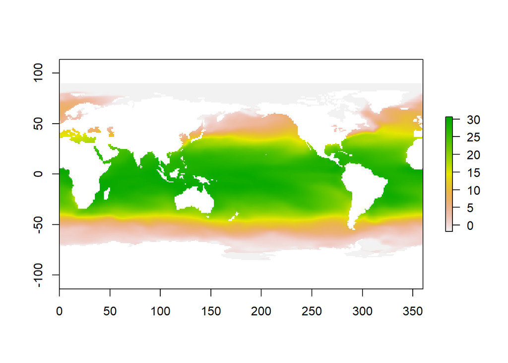

```r
plot(sst)
```

The default colour scale is horrendous so we will change it to the viridis scale. And add a title to the graph.

Here’s an example of using `::`. I don’t need the entire `viridis` package. This is to make a continuous colour palette of 20 colours.

That’s better

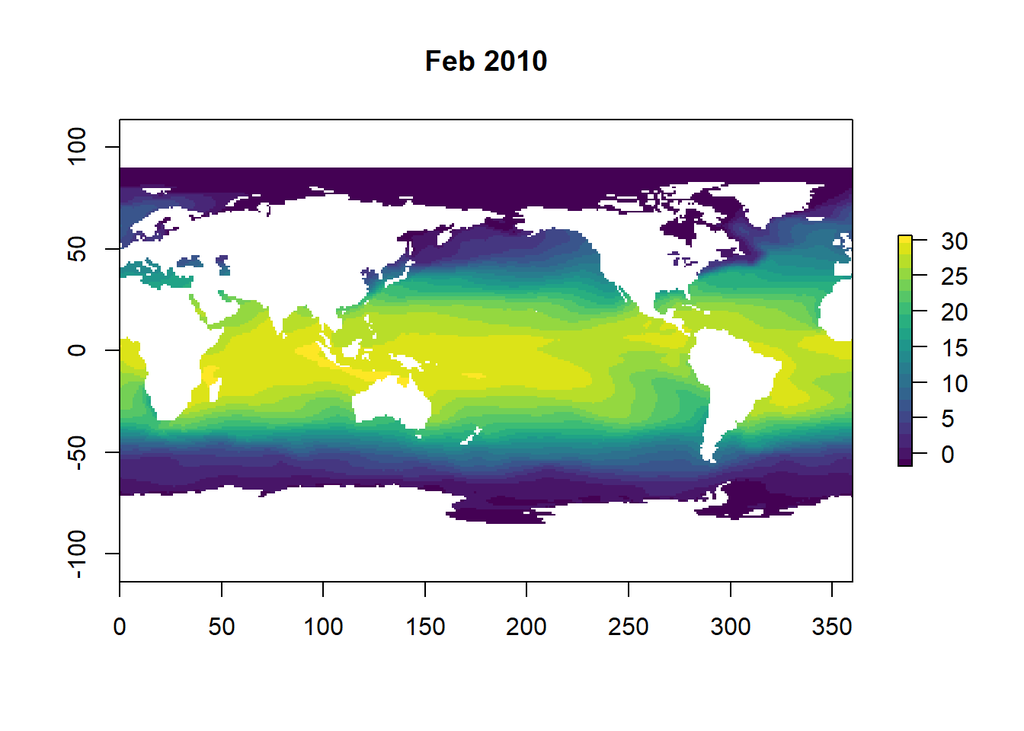

```r
plot(sst, main = "Feb 2010", col = viridis::viridis(n = 20))
```

Now we can get our spatial points.

# Spatial point data

I usually encounter spatial data in the form of decimal latitude and longitudes representing species occurrences or sampling sites. You may already have these data from your own work but for demonstration purposes I will show how to query an online database to get species distribution points from GBIF. This requires an Internet connection and the R package `rgbif`.

To be extra.

[figure not shown]

Image from Wikipedia

Let’s query GBIF occurrence points for an iconic tropical reef fish: The humphead wrasse (*Cheilinus undulatus*). That way we can get a wide tropical distribution in the Indo-Pacific region.

- You need the unique identification key for the species you want. `name_suggest` can help with that so you don’t have to manually search GBIF.
- The data comes as a list with some metadata. `.$data` is the actual occurrence records.

  The dot `.` is a placeholder meaning it represents an R variable (e.g. a dataframe). This is commonly used in `tidyverse` and piping via `magrittr`. It is also a cheat’s way of using base functions within a pipe
- Co-ordinates are stored as `decimalLatitude` and `decimalLongitude`. I’ve removed any missing values.

```r
library(rgbif)
# get ID key for fish
fish_key <- name_suggest(q ="Cheilinus undulatus", rank='species')$data$key[1]
# get occurence points
fish_points <- occ_search(taxonKey = fish_key) # Get all records, max 500 (see variable limit)
# exclude metadata
fish_points <- fish_points$data
# remove NA latitude or longitude
fish_points <- fish_points[!is.na(fish_points$decimalLatitude),]
```

Since I’ve only searched for one species, the workflow is simple.

If I wanted multiple species I would have to use lists and a function like `sapply`. See help file for `occ_search` for an example. Avoid for loops.

## Plot spatial data

Let’s look at the global distribution of points. I will use the base `maps` package for a simple, low resolution and unprojected world map in R (not recommended for more professional output)

The `maps` package can also be used in `ggplot2` via `borders(database = "world", fill = NA)` or `geom_polygon(data = map_data("world"), aes(x=long, y = lat, group = group), fill = NA, col= 1)`; `coord_map()` may help in these cases.

For more advanced mapping in R check out `ggmaps`, which can interface with Open Street Maps (free) and Google Maps (for a fee), and `osmdata`, which interfaces directly with OSM and allows you to customise which features to include - check out the related tutorial about mapping cities in R in the Space Club folder or [online](https://jacintak.github.io/post/2021-07-01-OSM-in-R/).

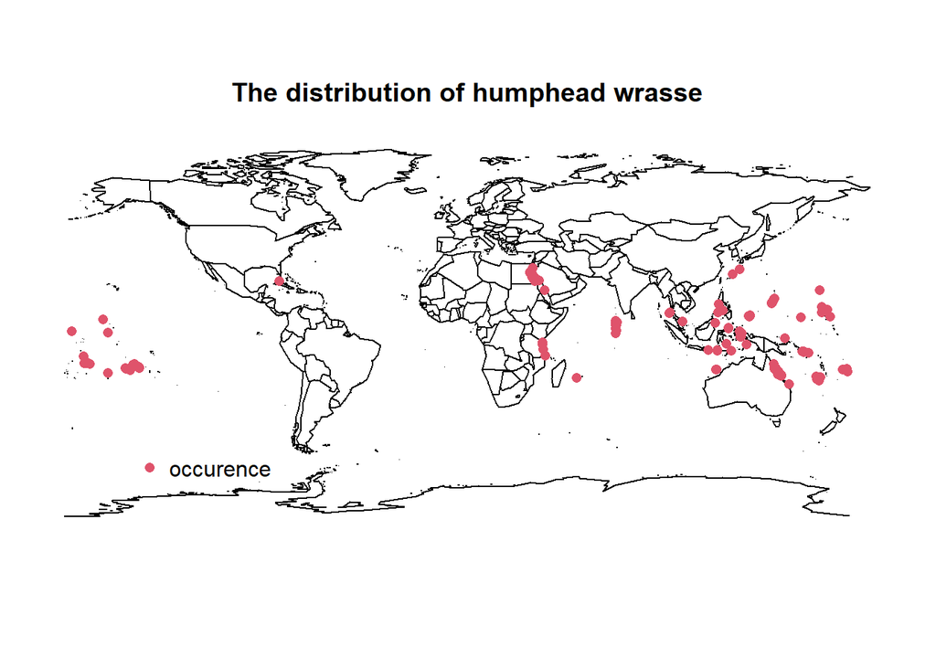

```r
library(maps)
map("world") # get basic world map
title(main = "The distribution of humphead wrasse") # plot title
points(decimalLatitude ~ decimalLongitude, fish_points, pch = 16, col = 2) # plot points
legend(x = -150, y= -50, legend = "occurence", pch = 16, col = 2, bty = "n")
```

# Putting it all together

Now we have all the data we need, let’s combine the datasets and plot the occurrence data with the SST raster.

The distribution of humphead wrasse with sea surface temperature

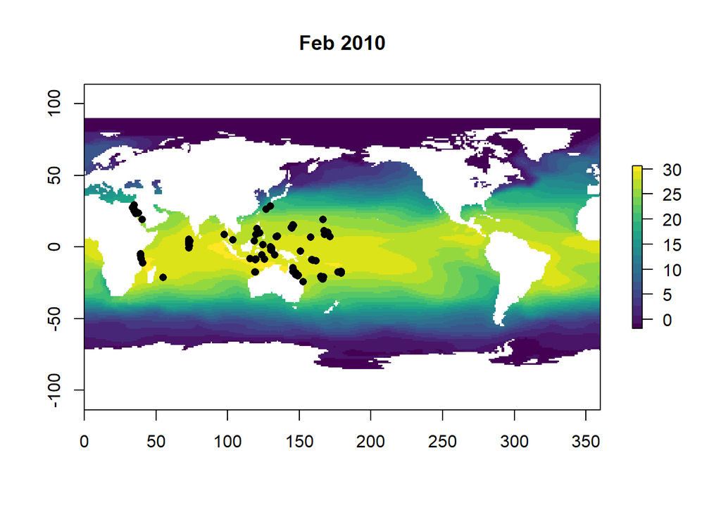

```r
plot(sst, main = "Feb 2010", col = viridis::viridis(n = 20)) # SST
points(decimalLatitude ~ decimalLongitude, fish_points, pch = 16, col = 1) # fish
```

Let’s do some simple extraction of data.

## What range of water temperatures do wrasses live in?

We can use our new species distribution points to query the raster and extract values corresponding with the occurrence points. The function to query a raster is `raster::extract`.

The same can be used within `tidyverse` via `mutate`.

`method = “bilinear”` tells the function to interpolate the average of the nearest 4 cells around the spatial point. This is like a mini version of `buffer` which will interpolate values within a buffer around a point. If spatial accuracy is not paramount (like here where we have a global scale raster), then this method might reduce the chance of extracting a `NA` value. The default is to query the exact coordinate.

```r
# Get SST
temps <- extract(sst, SpatialPoints(cbind(fish_points$decimalLongitude, fish_points$decimalLatitude)), method = "bilinear")
# Add new column
fish_temps <- cbind(fish_points, temps)
# Remove missing temps
fish_temps <- fish_temps[!is.na(fish_temps$temps),]
```

Our final dataset contains 292 observations.

We’ve lost nearly half the observations.

Missing data at this stage could be from a mismatch between the accuracy of the spatial points and the resolution of the raster. Or plain errors in the spatial coordinates.

Now we can plot the distribution of temperatures:

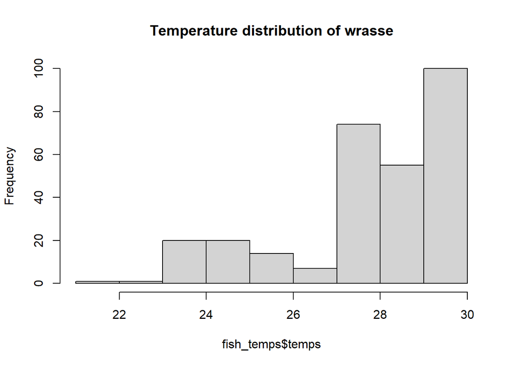

```r
hist(fish_temps$temps, main = "Temperature distribution of wrasse")
```

We can see they live in nice and warm waters between 21.2 and 29.8 °C.

Finally, we can plot the relationship between temperature and latitude:

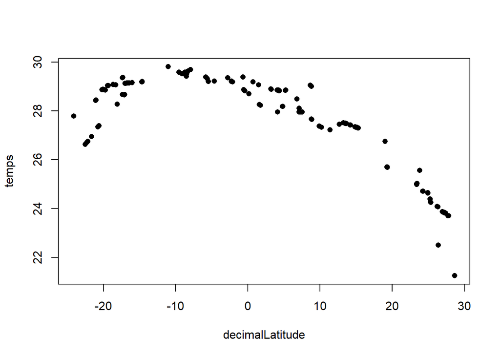

```r
plot(temps ~ decimalLatitude, fish_temps, pch = 16)
```

> End